# Reproducible Research: Peer Assessment 1

## Loading and preprocessing the data

```r
data <- read.csv("/Users/xiangjiang/Documents/git/RepData_PeerAssessment1/activity.csv")
```

## What is mean total number of steps taken per day?

### Make a histogram of the total number of steps taken each day

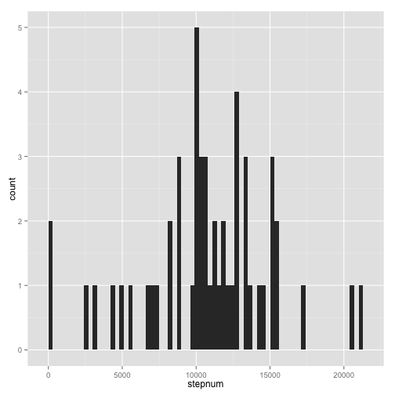

```r
library(ggplot2)
## Using tapply to calculate sum steps per day
steps <- tapply(data$steps, data$date, sum)
dfsteps <- data.frame(names(steps), steps, row.names = NULL)
names(dfsteps) <- c("date", "stepnum")
## Using qplot to plot histogram
qplot(stepnum, data = dfsteps, geom = "histogram", binwidth = 300)
```

### Calculate and report the mean and median total number of steps taken per day

Mean steps taken per day:

```r
mean(steps, na.rm = TRUE)
```

```
## [1] 10766
```

Median steps taken per day:

```r
median(steps, na.rm = TRUE)
```

```
## [1] 10765
```

## What is the average daily activity pattern?

Make a time series plot (i.e. type = “l”) of the 5-minute interval (x-axis) and the average number of steps taken, averaged across all days (y-axis)

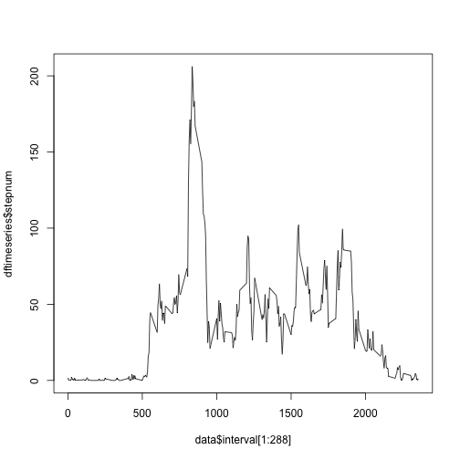

```r
timeseries <- tapply(data$steps, data$interval, mean, na.rm = TRUE)
dftimeseries <- data.frame(names(timeseries), timeseries, row.names = NULL)
names(dftimeseries) <- c("interval", "stepnum")
plot(data$interval[1:288], dftimeseries$stepnum, type = "l")
```

Which 5-minute interval, on average across all the days in the dataset, contains the maximum number of steps? The max number of steps are:

```r
max(dftimeseries$stepnum)
```

```
## [1] 206.2
```

The interval for the max steps are:

```r
a <- which.max(dftimeseries$stepnum)
names(a)
```

```
## [1] "835"
```

## Imputing missing values

Calculate and report the total number of missing values in the dataset The total number of missing values are:

```r
length(data$steps[is.na(data$steps)])
```

```
## [1] 2304
```

Devise a strategy for filling in all of the missing values in the dataset. Replace missing value with mean steps per interval.

```r
## replace missing value with mean steps per interval
data$steps[is.na(data$steps)] <- dftimeseries$stepnum[as.character(data$interval[is.na(data$steps)])]
```

Create a new dataset that is equal to the original dataset but with the missing data filled in.

```r
newdata <- data
```

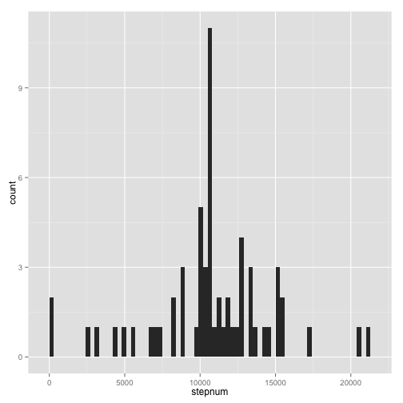

```r
## Using tapply to calculate sum steps per day
steps <- tapply(newdata$steps, data$date, sum)
dfsteps <- data.frame(names(steps), steps, row.names = NULL)
names(dfsteps) <- c("date", "stepnum")
## Using qplot to plot histogram
qplot(stepnum, data = dfsteps, geom = "histogram", binwidth = 300)
```

## Are there differences in activity patterns between weekdays and weekends?

Create a new factor variable in the dataset with two levels – “weekday” and “weekend” indicating whether a given date is a weekday or weekend day.

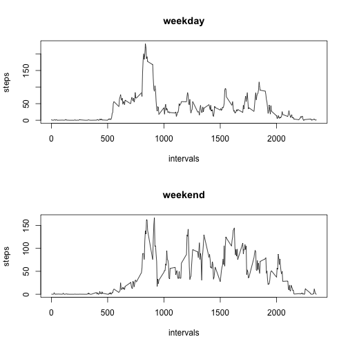

```r
## create factor variable *days* for weekends and weekdays
days <- weekdays(as.Date(as.character(newdata$date)))
weekends <- (days == "Sunday" | days == "Saturday")
days[weekends] <- "weekend"
days[!weekends] <- "weekday"
## calculate average number of steps

timeseries <- tapply(newdata$steps, list(data$interval, days), mean, na.rm = TRUE)
dftimeseries <- data.frame(timeseries)
par(mfrow = c(2, 1))
plot(row.names(dftimeseries), dftimeseries$weekday, type = "l", xlab = "intervals",
    ylab = "steps", main = "weekday")
plot(row.names(dftimeseries), dftimeseries$weekend, type = "l", xlab = "intervals",
    ylab = "steps", main = "weekend")
```